# ST Neural-ART NPU - Weights encryption support

3.0.0  
ST Neural-ART NPU - Weights encryption support

- Introduction
  - Why encrypt weights?
  - How the ST Neural-ART accelerator™ can help?
    - Role of the NPU complier
    - Role of the application developer
  - Encryption algorithm description and parameters
    - Important remarks
  - Supported features and limitations
- Encrypting weights
  - Requirements
  - Limitations
  - Hands-on: Encryption
    - Generate, for encrypted inference
    - Encrypt weights
    - Load the model on board
    - Running an inference
- LL ATON runtime API extension
  - Encrypted transfers during the inference
  - Encrypting manually a buffer
    - Easy case
    - Tricky case: Encrypting for external flash
- Final remarks

# ST Neural-ART NPU - Weights encryption support

for STM32 target, based on ST Edge AI Core Technology 3.0.0

r1.0

- STM32N6 with Neural-ART accelerator™

# Introduction

This article describes the low-level services and API that enable the NPU encryption/decryption unit to deploy encrypted weights. Encryption of the activations and/or isolation of the NPU stack, including the model itself, the management, and provisioning of the requested keys, is out of scope for this article.

- *“Encrypting weights”* section describes the services (Python-script based) and ready-to-use flow to encrypt the weights in a typical N6-DK development environment.
- “*LL ATON runtime API extension*” section describes the extension of the LL ATON API to use the NPU encryption/decryption unit.

## Why encrypt weights?

Encrypting weights is a good practice if intellectual property protection is required. Indeed, the weights of a model are usually the outcome of a thorough and time-consuming training phase that leads to a fine-tuned model fitting perfectly the use-case addressed.

## How the ST Neural-ART accelerator™ can help?

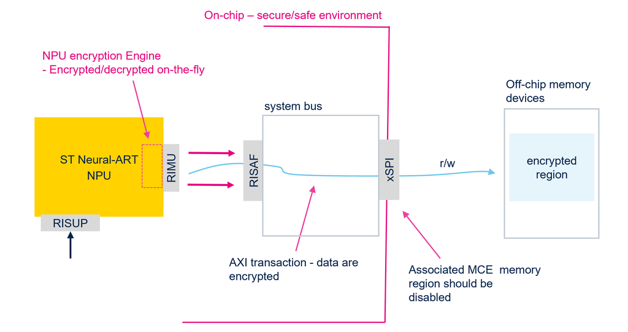

Data encryption

Note

Note that there are two bus interfaces and that both of them can be configured with keys. The stream engines 0-4 use bus interface 0 (and the associated keys), the stream engines 5-9 and the epoch controller use bus interface 1 (and the associated keys).

### Role of the NPU complier

To *support the encryption of the weights*, the *NPU compiler* provides a specific option (`'–-encrypt-weights'`) which generates the extra code needed to configure the stream engines to fetch the encrypted data and decrypt them on-the-fly for the processing units. Only three or four cycles of latency are added. With this option, all weights/parameters regions are considered encrypted by the NPU compiler. For the software epochs, as the weights cannot be decrypted by the MCU, extra epochs are generated to decrypt the used weights in a specific activation memory region, allowing direct access. This additional activation region is used temporarily during the processing time, increasing the requested memory size.

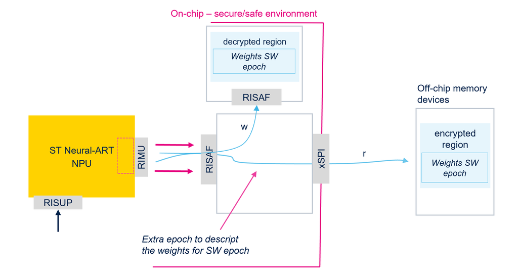

Software epoch encryption

Warning

The process of using extra epochs to decrypt a memory region for a software component can also be applied to certain parameters (excluding weights) needed to configure a specific processing unit. However, this decryption process is not optimized by the NPU compiler, resulting in additional epochs that can significantly impact inference time. To mitigate this issue, you can use the `'--no-encrypt-acc-confs'` option. This option keeps the parameters unencrypted, allowing the software component to access them directly and avoid any additional overhead.

### Role of the application developer

At “installation” time, the integrator or application developer is in charge of encrypting the memory chunks associated with a weights/params region.  
At runtime, when performing an inference, one is only responsible for setting the keys on the bus interface before performing the inference.

## Encryption algorithm description and parameters

As stated above, the encryption algorithm is embedded in hardware in the NPU. Here is a short description of the parameters that shall be provided as inputs of the algorithm to perform an encryption.

| Parameter | Description |
| --- | --- |
| Data | The data to be encrypted |
| Address | The final address at which the data is stored |
| Encryption ID | Encryption algorithm salt |
| Rounds | Number of encryption rounds to be done (9 or 12) |
| Increment | Number of frames to encrypt before incrementing the encryption ID (0 means no increment) |
| Key selection | 2 keys are available on the bus interface, selects one out of the two |

Two keys can be stored on the bus interface and each key is 128-bit long.

### Important remarks

- The encrypted value depends on the *address*, this means that other things being equal, encryption may not provide the same result at two different addresses (that is, it is not possible to move encrypted weights around in memory otherwise decryption fails).
- Each parameter (except the address) should be kept as secret as possible. Leaking a parameter could make an attacker’s job easier.
- The encryption algorithm is *involutive*: encrypting with the same parameters twice output the original data. The encryption process is the same as the decryption process.
- *In the current implementation of the embedded low-level API, only the key values can be made to vary, other parameters are set to hardcoded values for simplicity*

## Supported features and limitations

- Only the weights/params can be encrypted, no support to encrypt/decrypt on-the-fly the activations (including the model it-self)
- No support to encrypt the blobs or/and bitstream for the epoch controller
- The same key should be used for the different bus interfaces
- For latency constraint, it is recommended to use the `'–-encrypt-weights'` and `'--no-encrypt-acc-confs'` options, to limit the overhead due to additional epochs.

# Encrypting weights

ST Edge AI Core CLI does not encrypt weights, encryption must be done using dedicated tools installed together with the CLI. A set of specific Python scripts is provided in the `$STEDGEAI_CORE_DIR/scripts/N6_encrypt` folder.

> `%STEDGEAI_CORE_DIR%` represents the root location where the ST Edge AI Core components are installed, typically in a path like `"<tools_dir>/STEdgeAI/2.1/"`.

## Requirements

Apart from an STM32N6-based board (for example, an [STM32N6570-DK](https://www.st.com/en/evaluation-tools/stm32n6570-dk.html) board), to use these scripts Python 3.9+ and the following modules are required (the Python distribution of STEdgeAI complies with this):

```
python >= 3.9
pyserial >= 3.5
protobuf >= 3.20.3
tqdm >= 4.64
```

## Limitations

The current tool only supports:

- Encryption of **one** memory initializer
- Encryption of memory initializer in the `.raw` format only
- Encryption of data in the range `[0x7000'0000, 0x7800'0000]` (address of external flash on the STM32N6-DK board when memory-mapped)

## Hands-on: Encryption

This section demonstrates how to adapt the flow presented in the getting started section.  
It is a prerequisite to have understood this article, for the current one to be easy to understand.

The global flow is very similar to the original one:

1. Generate
2. **Encrypt weights**
3. Load the model on board
4. Validate

### Generate, for encrypted inference

**When generating code using encryption the `--encrypt-weights` option has to be added in the profile used during generation.**

```bash
$> stedgeai generate -m MYMODEL.tflite --target stm32n6 --st-neural-art my_profile@my_profiles.json
```

The generation process produces (in the output directory) files that are needed for the encryption step:

- `c_info.json` file representing some information about code generation done
- `*.raw` files containing the weights to be programmed on board, *unencrypted*

### Encrypt weights

For this step, *it is required to have an STM32N6 board (for example, STM32N6-DK)* connected to the computer.

`$STEDGEAI_CORE_DIR/scripts/N6_encrypt` folder contains:

- A `c` subfolder including the embedded project used for encryption (delivered as source if ever needed),
- A `python` folder including the scripts that should be used by users (also delivered as source if ever needed)
  - `end_to_end_encrypt.py` is the recommended script to use for easy encryption

Launching the tool encrypts a `.raw` file and replace the original file by the encrypted one (the original plain file is then available in the `.unencrypted` file created).  
The encrypted file can then be used as-is in the next step using the `n6_loader.py`.

```bash
$> python end_to_end_encrypt.py --cubeide C:/ST/STM32CubeIDE_1.17.0/STM32CubeIDE --postprocess C:/stai/st_ai_output/network_c_info.json C:/stai/st_ai_output/network_atonbuf.xSPI2.raw

17:29:40.128 :: cubeIDE_toolbox.py :: INFO     :: Resetting the board
17:29:40.977 :: cubeIDE_toolbox.py :: INFO     :: Starting GDB server
17:29:41.132 :: cubeIDE_toolbox.py :: INFO     :: Starting GDB client
17:29:42.351 :: end_to_end_encrypt.py :: INFO     :: Waiting for the firmware to initialize
17:29:43.352 :: end_to_end_encrypt.py :: INFO     :: Starting encryption script
17:29:43.353 :: encrypt_neural_art.py :: INFO     :: Parsing c_info file
17:29:43.368 :: encrypt_neural_art.py :: INFO     :: Memory pool to encrypt found at address: 0x71000000 -- 20.142 kBytes to encrypt at offset 0
17:29:43.399 :: encrypt_neural_art.py :: INFO     :: Starting encryption
17:29:43.399 :: encrypt_neural_art.py :: INFO     :: Sending encryption params: keys = (MSB:0xaabbccddaabbccdd)(LSB:0xaabbccddaabbccdd) -- nb_rounds = 12
17:29:43.619 :: encrypt_neural_art.py :: INFO     :: Data transfer finished -- Took 0.197 seconds -- size = 20.142kB -- Encryption rate: 102.242kB/s
17:29:43.620 :: encrypt_neural_art.py :: INFO     :: Encrypted data injected into network_atonbuf.xSPI2_encrypted.raw
17:29:43.620 :: encrypt_neural_art.py :: INFO     :: Done
17:29:43.621 :: end_to_end_encrypt.py :: INFO     :: Postprocessing the files
17:29:43.621 :: end_to_end_encrypt.py :: INFO     :: Backup of original unencrypted weights: network_atonbuf.xSPI2.raw -> network_atonbuf.xSPI2.unencrypted
17:29:43.621 :: end_to_end_encrypt.py :: INFO     :: Replacing original file with encrypted weights: network_atonbuf.xSPI2_encrypted.raw -> network_atonbuf.xSPI2.raw
17:29:43.659 :: end_to_end_encrypt.py :: INFO     :: Done
```

**end_to_end_encrypt.py details**

#### `end_to_end_encrypt.py` command-line interface

```
usage: end_to_end_encrypt.py [-h] [-v] [-k KEYS KEYS] [-r NBROUNDS] [-p COMPORT] --cubeide CUBEIDE [--skip_debug] [--postprocess] [--flash] c_info raw_file

End-To-End encryption tool for weights using Neural Art

positional arguments:
  c_info                json file output of the compilation
  raw_file              memory-initializer file output of the compilation (.raw)

optional arguments:
  -h, --help            show this help message and exit
  -v, --verbose         Increase output verbosity (debug) (default: False)
  -k KEYS KEYS, --keys KEYS KEYS
                        Keys to use (MSB LSB) (default: [12302652059516914909, 12302652059516914909])
  -r NBROUNDS, --nbrounds NBROUNDS
                        Number of rounds (ignored for now) (default: 12)
  -p COMPORT, --comport COMPORT
                        COM-port name to be used for transmitting data to STLink. auto tries to connect to the first "STLink" found. (default: auto)
  --cubeide CUBEIDE     Path to cubeIDE install dir (default: None)
  --skip_debug          Skip loading the encryption tool elf file to the board (default: False)
  --postprocess         Postprocess the files to use them with the n6_loader script (default: False)
  --flash               After postprocessing, flash the encrypted weights to the board (default: False)
```

Positional arguments shall be provided at all costs. Those are some of the outputs of the `generate` step above.

- `*_c_info.json`: contains information about memory pools and possible encryption to be considered. The full path to this file shall be provided.
- `.raw` files: the one containing the weights (that should be encrypted) shall be given to the tool. The full path to this file shall be provided.

Two optional arguments should also be provided in most cases:

- `--cubeide` shall be provided to allow programming the encryption firmware to the board. The full path to CubeIDE (*path ending with STM32CubeIDE*) should be provided.
- `--postprocess` shall be provided to allow compatibility of the outputs with the next `n6_loader.py` call.

The remaining arguments can be provided (or not):

- `--help` shows the usage information provided above
- `--verbose` makes the tool verbose, useful for debug.
- `--skip_debug` can be used to ignore the step where the encryption firmware is programmed on the board (cubeide is not required if this option is used)
- `--flash` can be used to automatically flash the encrypted weights on board (not used if `n6_loader.py` is to be used afterwards, but could be useful depending on the use case)
- `--comport` can be used to specify the communication port to use (useless if only one STLINK is connected to the computer)

Finally, it is possible to change the encryption parameters:

- `--keys KEYS KEYS` to change the keys to be set on bus interfaces for encryption. The keys are 128-bit values, two half-keys shall be provided (MSB/LSB). *The default values are `0xaabbccddaabbccdd`, `0xaabbccddaabbccdd`, which are the keys set by default in the NPU_Validation_project`* meaning this argument is not needed if the goal is to do a “validation on target”.
- `--nbrounds NBROUNDS` (*ignored for the current version*) can be used to change the number of rounds done in the encryption algorithm.

#### `end_to_end_encrypt.py` function

This script will:

- Discover tools provided with cubeIDE (gdb-server, gdb, cubeprogrammer)
- Using gdb-server and gdb, load the `.elf` file provided in the `c/` directory (encryption firmware)
- Parse the `*c_info.json` file to find the first memory-pool to be encrypted in the memory range `[0x7000'0000, 0x7800'0000]`
  - Within this memory pool, find where is the data to be encrypted
- Send encryption parameters to the encryption firmware (this will set the keys used for encryption during this session)
- Split the data in the `.raw` file provided in chunks of 4 kbyte from the address found above
- Send each chunk along with its final address on target to the encryption firmware
- (The encryption firmware receives the chunk, perform the encryption, sends it back to the Python script through UART)
- Receive the encrypted chunk
- Rebuild the whole encrypted file
  - Move the initial `.raw` unencrypted file to `.unencrypted`
  - Store the encrypted file to the initial `.raw` file
- if `postprocess` option is passed, change timestamps for all the files generated by the generation phase to allow the `n6_loader` to function properly
- if `flash` option is passed, use cube programmer to flash the encrypted weights on board.

### Load the model on board

After encrypting the weights (*do not forget to use `--postprocess` in the script above*), the standard flow described in the getting started applies:

```bash
$> python n6_loader.py --n6-loader-config config_n6l.json
```

### Running an inference

Since the NPU_Validation_project is “encryption-ready” (using default bus interface keys), it is now possible to perform a validation on target:

```bash
$> stedgeai validate –m MYMODEL.tflite --target stm32n6 --mode target --desc serial:921600 --val-json st_ai_output/network_c_info.json
```

# LL ATON runtime API extension

Most functions concerned by encryption are defined in `ll_aton_cipher.c`.

## Encrypted transfers during the inference

When using the ST Neural-ART compiler with the `--encrypt-weights` option, the generated `"network.c"` file most likely contains calls to the `LL_Streng_WeightEncryptionInit()` function. These calls, automatically generated by the NPU compiler, are inserted as requested after configuring the stream engine (also known as DMA) transfer to enable an encrypted transfer (ciphertext).

In the current version, the implementation of this function is lightweight and contains hard-coded values for the encrypted transfer:

- Encryption ID is set to 0
- Encryption rounds are set to 12
- The key selected is the one with the index 0
- The encryption ID increment is set to 0 (no increment)

The transfers that are overloaded with this “decryption” decorator are then done using the key with the index 0. Such a key must be programmed on the bus interfaces, using the following function:

```c
LL_Busif_SetKeys ( int bus_interface_no , int key_id , uin64_t busif_lsb_key , uint64_t busif_msb_key );
```

The bus interfaces shall be configured before launching an inference for the encrypted transfers to be done with the correct keys.  
More precisely, this configuration shall be done after the bus interfaces are initialized/clocked, and before doing any encrypted stream-engine transfer *i.e.* after calling `LL_ATON_RT_RuntimeInit` and before the executing the first epoch of an inference.  
By default, in the *NPU_Validation* project, the default keys used are as follows:

```c
#define BUSIF_LSB_KEY      0xAABBCCDDAABBCCDD
#define BUSIF_MSB_KEY      0xAABBCCDDAABBCCDD

// ...
// LL_ATON_RT_RuntimeInit();
// ...
// Set key at index 0 (the only one used by LL_Streng_WeightEncryptionInit)
LL_Busif_SetKeys ( 0 , 0 , BUSIF_LSB_KEY , BUSIF_MSB_KEY );     // Set key on busif 0: for STRENG 0-4
LL_Busif_SetKeys ( 1 , 0 , BUSIF_LSB_KEY , BUSIF_MSB_KEY );     // Set key on busif 1: for STRENG 5-9+Epoch controller
```

Encrypted transfers will then use the key stored on the interface. It is a good practice to use the same key on both bus interfaces otherwise decrypting transfers done with different stream engines will not work. Nonencrypted transfers will just pass through the interface without using the encryption key (the configuration of the bus interface keys does not prevent doing plain, unencrypted, transfers).

## Encrypting manually a buffer

Note

Since the address of the data is an input of the encryption algorithm, when doing a transfer to encrypt a buffer, the transfer shall be done towards (or from) the final address where this buffer will be stored at.

### Easy case

For most cases (except when dealing with weights stored in flash – see below), doing a data transfer to encrypt a buffer is straightforward.  
`ll_aton_cipher` provides `int LL_DmaCypherInit(LL_Cypher_InitTypeDef *cypherInfo)` that can be used to do a stream engine transfer to encrypt data.

The argument of this function is of type `LL_Cypher_InitTypeDef`:

```c
typedef struct {
    uint32_t srcAdd;                       /**< Transfer source address */
    uint32_t dstAdd;                       /**< Transfer destination address */
    uint32_t len;                          /**< Transfer size */
    CypherCacheSourceMask cypherCacheMask; /**< Cache usage mask:
                                            *     0-no cache
                                            *     1-cache source
                                            *     2-cache destination */
    CypherEnableMask cypherEnableMask;     /**< Cyphering channel mask:
                                            *     0-no cypher
                                            *     1-cypher source
                                            *     2-cypher destination */
    uint64_t busIfKeyLsb;                  /**< Bus interface LSB Key */
    uint64_t busIfKeyMsb;                  /**< Bus interface MSB Key */
  } LL_Cypher_InitTypeDef;
```

- `srcAdd`, `dstAdd` and `len` are used respectively for the source address, the destination address and the transfer size.
- `cypherEnableMask` can be used to activate cyphering: the address used for encrypting weights can be either the source or the destination address depending on the use-case.
- `cypherCacheMask` should not be used for the standard case (not triggering encryption of external-flash-bound weights).

The last two fields contain the bus interface key to use: 2x64-bits = 128 bits. This function returns when the data transfer is over.

### Tricky case: Encrypting for external flash

Encrypting to external flash can be tricky because it is not possible for the stream engines to write directly to external flash. Capability to write in an external FLASH through the XSPI interface in memory-mapped mode is not guarantee.

*One solution* is to store the plaintext to external FLASH at the final address and encrypts it using the source address as a parameter TO a buffer in internal RAM. The resulting buffer stored in RAM could then be written to flash by the CPU, at the final address. The drawback of this solution is that the unencrypted data is stored in the FLASH for a given period.

**Advanced trick**: not using the flash memory at all**

If it is required (or preferred) not to use the external flash at all, it is also possible to do the following (which is what is done in the encryption firmware provided). Assume the buffer to be encrypted is in RAM, and should be placed in the final application, encrypted in external flash. It is then possible to do an encryption transfer using the final destination address as the parameter for encryption and to *force the stream engine to write in the AXICACHE* cache. This is done by using the `cypherCacheMask` and set it to use cache for the final destination address, that is, the write is routed to cache instead of external flash.

This overcomes the need to access to external flash: the *encrypted buffer* is stored in AXICACHE lines.  
This can then be retrieved by doing a simple stream-engine transfer (non encrypting) that will get the encrypted AXICACHE lines (see `dma_memcpy_with_streng` in `Weights_encryption/FSBL/Core/Src/encrypt.c`), by routing the read to the AXICACHE instead of reading from the external flash.

To use this trick:

- The amount of encryption to be done at once shall not exceed the cache size: 256 Kbyte = `0x40000` bytes
- Do not explicitly *clean* a dirty cache containing data bound for external flash, or the system will hang.
- Extra care should be taken to prevent any eviction of a line that should be written to external flash, or everything will hang. (The cache should be invalidated before doing a new refill, or fully reset).

# Final remarks

The source code for both the embedded project and the Python tool are provided as-is.  
They are provided, for example, purpose and it is not needed to understand their function to use the tool.

If ever needed, the communication protocol is written using protobuf and nanopb libraries to easily generate bindings for embedded C and Python.

For generating/modifying python/c bindings for the protocol defined, extra modules are needed:

- protobuf>=5.29.3
- grpcio-tools
- nanopb==0.4.9.1 (download it from [here](https://jpa.kapsi.fi/nanopb/download/))

**The tool uses the `".elf"` file generated by the embedded project, erasing it causes issues; modifying it may cause malfunctions**.

**ST Neural-ART NPU - Weights encryption support** - r1.0  
ST Edge AI Core Technology 3.0.0

Information in this document is provided solely in connection with ST products. The contents of this document are subject to change without prior notice. © Copyright STMicroelectronics 2025. All rights reserved. www.st.com